# IDS investigation worksheet

by Team-Name: User1, User2, User3, User4 & User5

2024-11-22

**Note:** You can use this file as you ‘working document’ where you can try out various investigation ideas and keep notes about your findings. How you use and structure this file is up to you. It is recommended that you keep notes about what you are investigating and what you find as this will make the process of creating your presentation and report easier. Please note that you *do not* need to submit this file as part of your group project.

```r
library(tidyverse)
library(readr)
library(dplyr)
library(janitor)
library(tidymodels)
```

```r
olympics <- read_csv("data/olympics.csv", show_col_types = FALSE)
```

```r
olympics_medals <- olympics %>%
  drop_na()

#finding win percentage overall
olympics %>%
  group_by(medal) %>%
  summarise(count = n()) %>%
  mutate(win_pct = count/sum(count) * 100 )
```

```
## # A tibble: 4 × 3
##   medal   count win_pct
##   <chr>   <int>   <dbl>
## 1 Bronze  13295    4.90
## 2 Gold    13372    4.93
## 3 Silver  13116    4.84
## 4 <NA>   231333   85.3
```

```r
# athletes by team
olympics %>%
  group_by(team) %>%
  summarise(count = n()) %>%
  mutate(team_pct = count/sum(count) * 100 ) %>%
  arrange(desc(team_pct))
```

```
## # A tibble: 1,184 × 3
##    team          count team_pct
##    <chr>         <int>    <dbl>
##  1 United States 17847     6.58
##  2 France        11988     4.42
##  3 Great Britain 11404     4.21
##  4 Italy         10260     3.78
##  5 Germany        9326     3.44
##  6 Canada         9279     3.42
##  7 Japan          8289     3.06
##  8 Sweden         8052     2.97
##  9 Australia      7513     2.77
## 10 Hungary        6547     2.41
## # ℹ 1,174 more rows
```

```r
# medals by team
olympics_medals %>%
  group_by(team) %>%
  summarise(count = n()) %>%
  mutate(medals_pct = count/sum(count) * 100 ) %>%
  arrange(desc(medals_pct))
```

```
## # A tibble: 263 × 3
##    team          count medals_pct
##    <chr>         <int>      <dbl>
##  1 United States  4273      14.2
##  2 Soviet Union   2203       7.30
##  3 Germany        1518       5.03
##  4 Australia      1196       3.96
##  5 Russia         1091       3.61
##  6 Canada         1024       3.39
##  7 Great Britain  1010       3.35
##  8 Italy          1008       3.34
##  9 France          965       3.20
## 10 East Germany    935       3.10
## # ℹ 253 more rows
```

```r
# teams in sports
olympics_medals %>%
  count(team, sport) %>%
  arrange(desc(n))
```

```
## # A tibble: 1,455 × 3
##    team          sport          n
##    <chr>         <chr>      <int>
##  1 United States Athletics   1004
##  2 United States Swimming     917
##  3 Australia     Swimming     349
##  4 United States Basketball   341
##  5 Canada        Ice Hockey   281
##  6 United States Rowing       265
##  7 Great Britain Athletics    254
##  8 Soviet Union  Athletics    238
##  9 United States Ice Hockey   236
## 10 Soviet Union  Gymnastics   233
## # ℹ 1,445 more rows
```

## Age Distribution

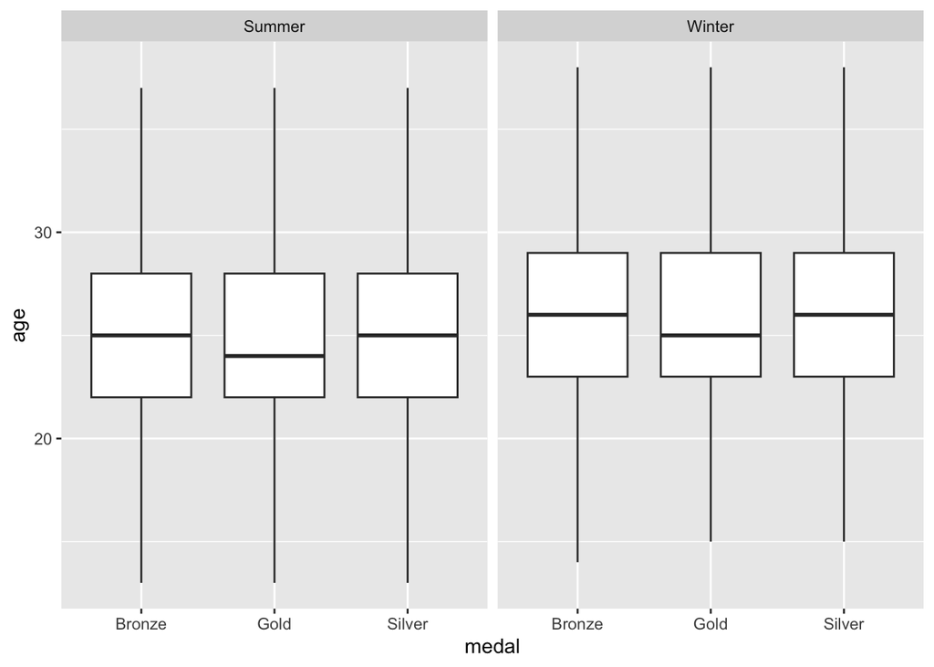

```r
# create plots using filtered dataset
filteredA %>%
  ggplot(mapping = aes(y = age, x = medal)) +
  geom_boxplot() +
  facet_wrap( ~ season)
```

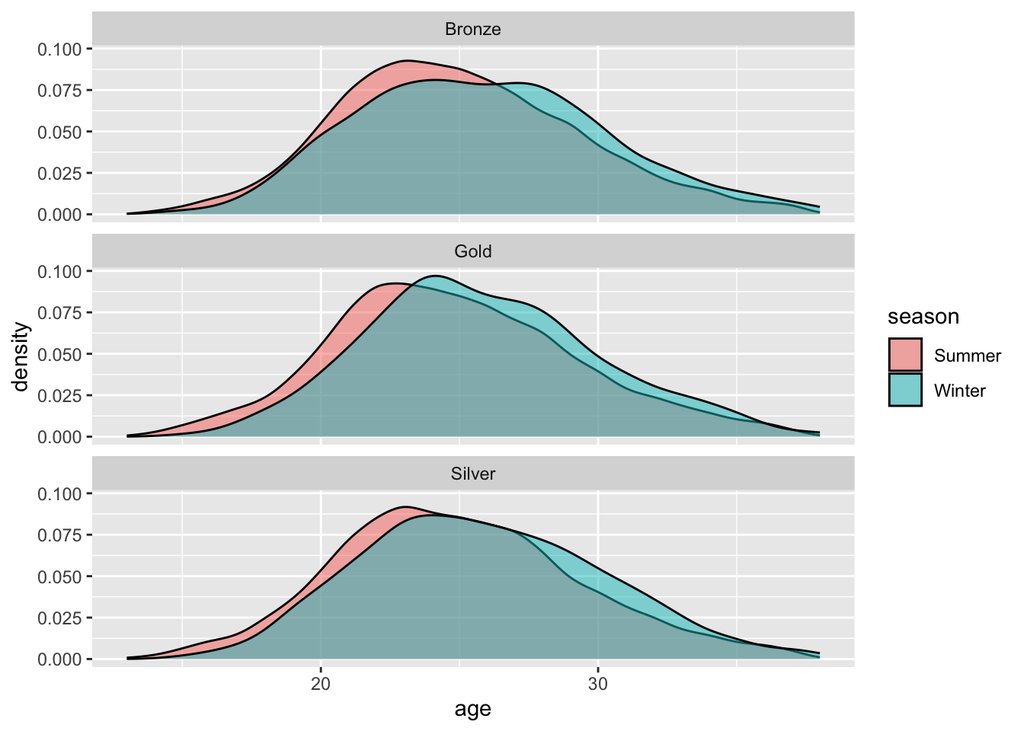

```r
filteredA %>%
  ggplot(mapping = aes(x = age, fill = season)) +
  geom_density(alpha = 0.5) +
  facet_wrap( ~ medal,
              ncol = 1)
```

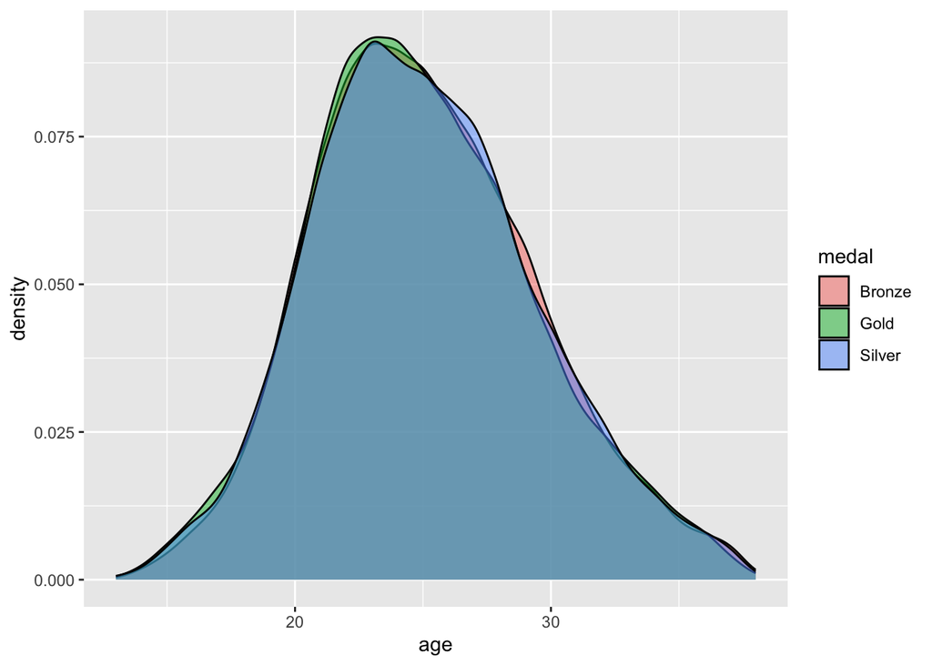

```r
filteredA %>%
  ggplot(mapping = aes(x = age, fill = medal)) +
  geom_density(alpha = 0.5)
```

```r
# find mean and median age for each combination of season and medal
filteredA %>%
  group_by(season, medal) %>%
  summarise(avg = mean(age),
            med = median(age))
```

```
## # A tibble: 6 × 4
## # Groups:   season [2]
##   season medal    avg   med
##   <chr>  <chr>  <dbl> <dbl>
## 1 Summer Bronze  25.0    25
## 2 Summer Gold    24.8    24
## 3 Summer Silver  24.9    25
## 4 Winter Bronze  25.8    26
## 5 Winter Gold    25.8    25
## 6 Winter Silver  25.8    26
```

```r
# find mean and median age for each season
filteredA %>%
  group_by(season) %>%
  summarise(avg = mean(age),
            med = median(age))
```

```
## # A tibble: 2 × 3
##   season   avg   med
##   <chr>  <dbl> <dbl>
## 1 Summer  24.9    25
## 2 Winter  25.8    26
```

```r
# find mean and median age for each season
filteredA %>%
  group_by(medal) %>%
  summarise(avg = mean(age),
            med = median(age))
```

```
## # A tibble: 3 × 3
##   medal    avg   med
##   <chr>  <dbl> <dbl>
## 1 Bronze  25.1    25
## 2 Gold    25.0    25
## 3 Silver  25.1    25
```

- More outliers in Summer Olympics than in Winter
- Avergae age of medal winners slightly higher in Winter Olympics (26) than in Summer (25)
- Almost no outliers below lower bound
- Remove outliers using Q1/Q3 -/+ 1.5IQR (this mostly targets outliers above upper bound)
- Distributions of age are closer to normal for each medal and season with differences between mean and median age not greater than 1 year
- For each medal, the average age of winner is between 24.98 and 25.11 years old

## Height Distribution

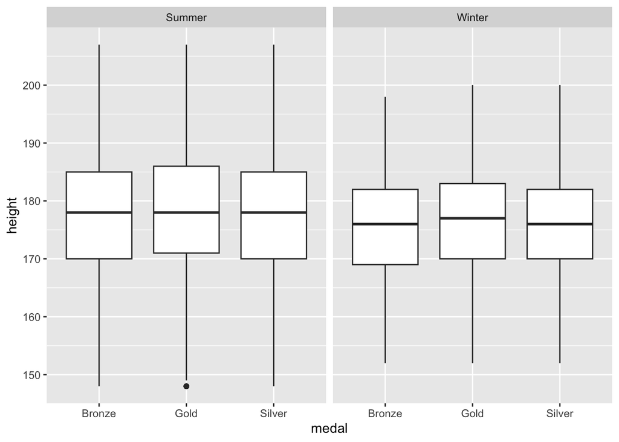

```r
filteredH %>%
  ggplot(mapping = aes(y = height, x = medal)) +
  geom_boxplot() +
  facet_wrap( ~ season)
```

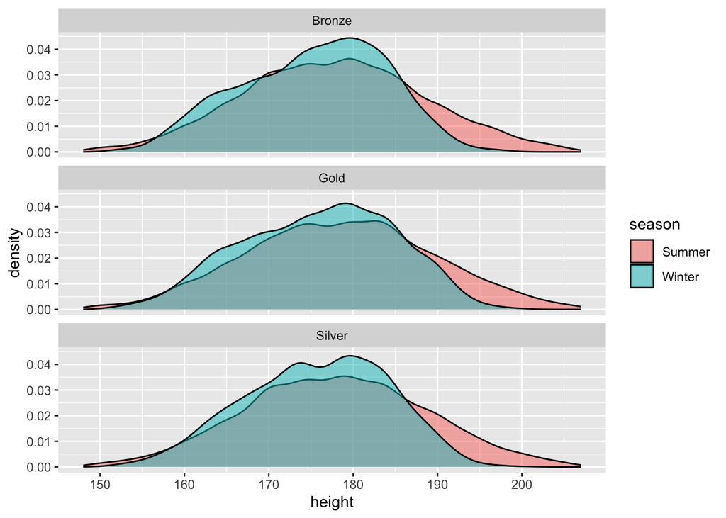

```r
filteredH %>%
  ggplot(mapping = aes(x = height, fill = season)) +
  geom_density(alpha = 0.5) +
  facet_wrap( ~ medal,
              ncol = 1)
```

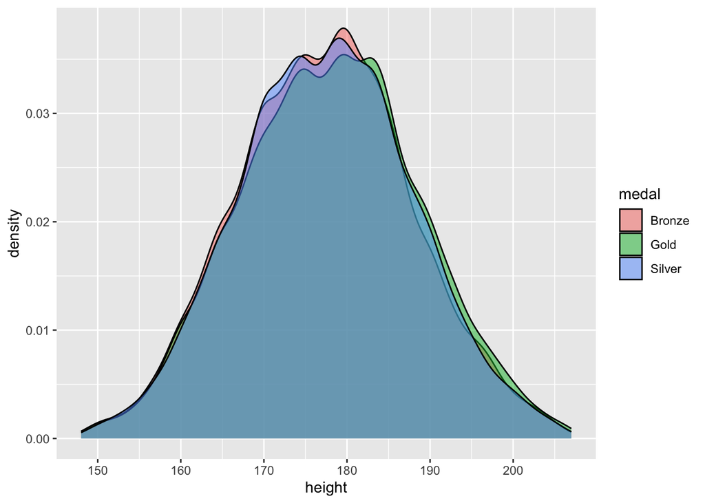

```r
filteredH %>%
  ggplot(mapping = aes(x = height, fill = medal)) +
  geom_density(alpha = 0.5)
```

```r
# find mean and median age for each combination of season and medal
filteredH %>%
  group_by(season, medal) %>%
  summarise(avg = mean(height),
            med = median(height))
```

```
## # A tibble: 6 × 4
## # Groups:   season [2]
##   season medal    avg   med
##   <chr>  <chr>  <dbl> <dbl>
## 1 Summer Bronze  178.   178
## 2 Summer Gold    178.   178
## 3 Summer Silver  178.   178
## 4 Winter Bronze  175.   176
## 5 Winter Gold    176.   177
## 6 Winter Silver  176.   176
```

```r
# find mean and median height for each season
filteredH %>%
  group_by(season) %>%
  summarise(avg = mean(height),
            med = median(height))
```

```
## # A tibble: 2 × 3
##   season   avg   med
##   <chr>  <dbl> <dbl>
## 1 Summer  178.   178
## 2 Winter  176.   176
```

```r
# find mean and median age for each season
filteredH %>%
  group_by(medal) %>%
  summarise(avg = mean(height),
            med = median(height))
```

```
## # A tibble: 3 × 3
##   medal    avg   med
##   <chr>  <dbl> <dbl>
## 1 Bronze  177.   178
## 2 Gold    178.   178
## 3 Silver  178.   178
```

- Very few outliers in winter olympics, a lot in summer on both ends of the distribution
- Remove outliers using Q1/Q3 -/+ 1.5IQR
- Range of heights greater for Summer Olympics athletes than Winter
- Average height slightly larger for Summer Olympics (178.0) than Winter (175.6)
- For each medal, the height distributions are close to normal in both seasons, with differences between mean and median of at most 1.1 cm
- For each medal, the average height of winner is between 177.3 and 178.0 cm

## Weight Distribution

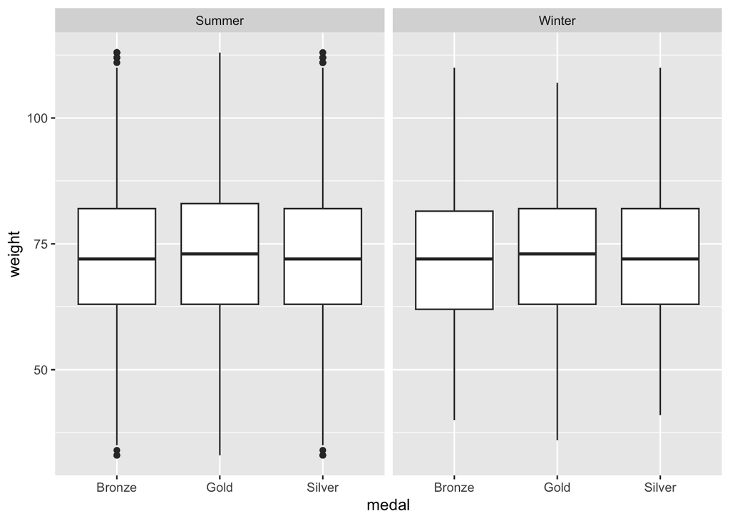

```r
filteredW %>%
  ggplot(mapping = aes(y = weight, x = medal)) +
  geom_boxplot() +
  facet_wrap( ~ season)
```

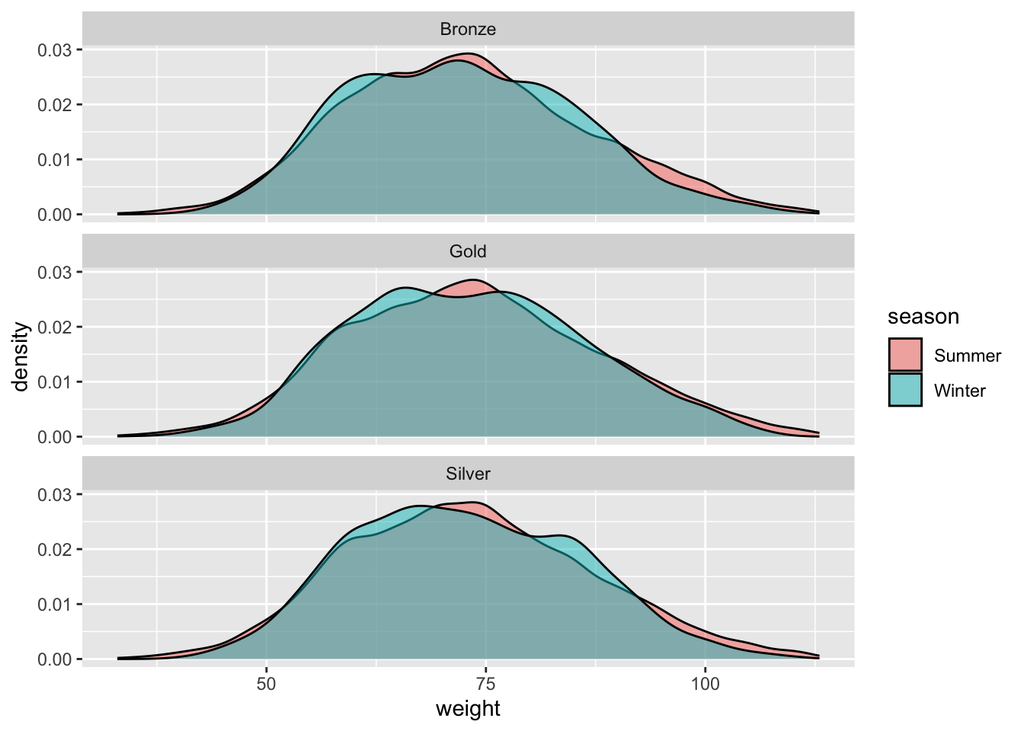

```r
filteredW %>%
  ggplot(mapping = aes(x = weight, fill = season)) +
  geom_density(alpha = 0.5) +
  facet_wrap( ~ medal,
              ncol = 1)
```

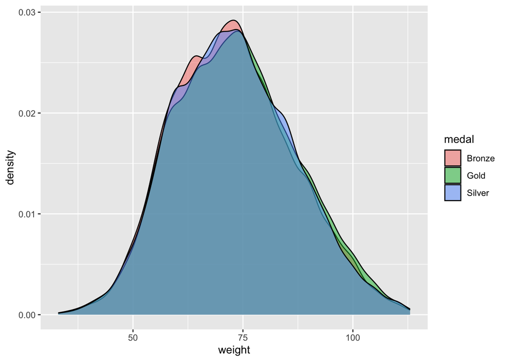

```r
filteredW %>%
  ggplot(mapping = aes(x = weight, fill = medal)) +
  geom_density(alpha = 0.5)
```

```r
# find mean and median weight for each combination of season and medal
filteredW %>%
  group_by(season, medal) %>%
  summarise(avg = mean(weight),
            med = median(weight))
```

```
## # A tibble: 6 × 4
## # Groups:   season [2]
##   season medal    avg   med
##   <chr>  <chr>  <dbl> <dbl>
## 1 Summer Bronze  72.8    72
## 2 Summer Gold    73.5    73
## 3 Summer Silver  73.0    72
## 4 Winter Bronze  72.3    72
## 5 Winter Gold    73.1    73
## 6 Winter Silver  72.7    72
```

```r
# find mean and median weight for each season
filteredW %>%
  group_by(season) %>%
  summarise(avg = mean(weight),
            med = median(weight))
```

```
## # A tibble: 2 × 3
##   season   avg   med
##   <chr>  <dbl> <dbl>
## 1 Summer  73.1    73
## 2 Winter  72.7    72
```

```r
# find mean and median weight for each season
filteredW %>%
  group_by(medal) %>%
  summarise(avg = mean(weight),
            med = median(weight))
```

```
## # A tibble: 3 × 3
##   medal    avg   med
##   <chr>  <dbl> <dbl>
## 1 Bronze  72.7    72
## 2 Gold    73.5    73
## 3 Silver  73.0    72
```

- Many outliers above upper bound in Summer Olympics, some below lower bound, but almost no outliers in Winter Olympics
- Remove outliers using Q1/Q3 -/+ 1.5IQR
- Range of athletes’ weights higher in Summer Olympics than in Winter
- Average weight slightly higher in Summer Olympics (73.1) than in Winter (72.7)
- For each medal, the weight distributions are close to normal in both seasons, with differences between mean and median of at most 1.03 kg
- For each medal, the average weight of winner is between 72.7 and 73.5 kg

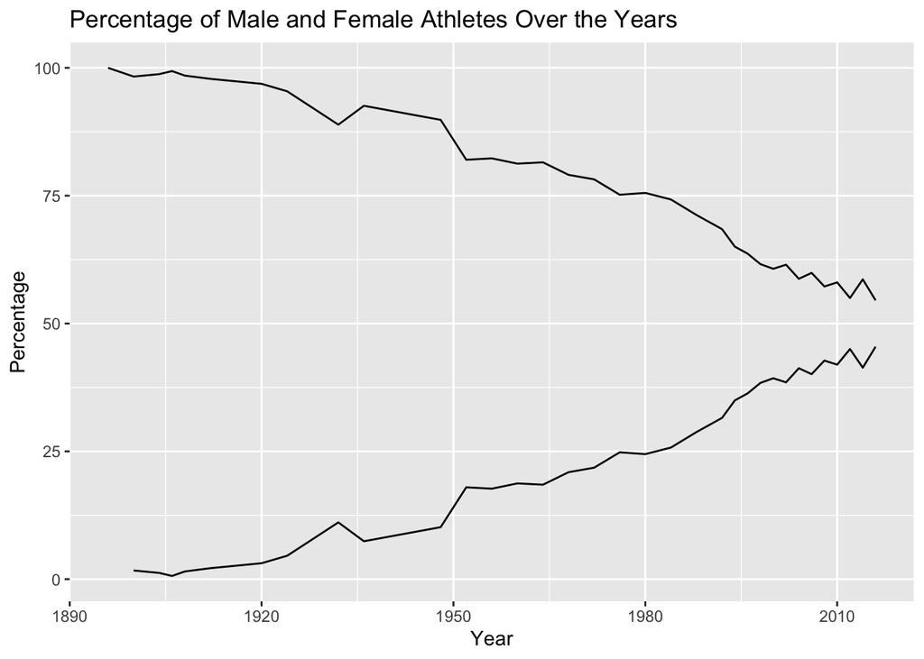

```r
olympics %>%
  group_by(year, sex) %>%
  summarise(count = n(), .groups = 'drop') %>%
  group_by(year) %>%
  mutate(percentage = count / sum(count) * 100) %>%
  ggplot(mapping = aes(x = year,  y = percentage, fill = sex)) +
  geom_line() +
  labs(
    title = "Percentage of Male and Female Athletes Over the Years",
    x = "Year",
    y = "Percentage",
    colour = "Gender"
  )
```

```r
# Load the dataset (adjust the file path as needed)
olympics_data <- olympics

# Data preparation: Aggregate medals by country and year
medals_data <- olympics_data %>%
  filter(!is.na(medal)) %>% # Keep only rows with medals
  group_by(year, team) %>% # Group by year and team (country)
  summarise(
    total_medals = n(), # Total medals won
    num_athletes = n_distinct(id), # Number of unique athletes
    avg_age = mean(age, na.rm = TRUE), # Average age of athletes
    avg_height = mean(height, na.rm = TRUE), # Average height
    avg_weight = mean(weight, na.rm = TRUE), # Average weight
    .groups = 'drop'
  ) %>%
  mutate(
    avg_age = ifelse(is.na(avg_age), mean(avg_age, na.rm = TRUE), avg_age),
    avg_height = ifelse(is.na(avg_height), mean(avg_height, na.rm = TRUE), avg_height),
    avg_weight = ifelse(is.na(avg_weight), mean(avg_weight, na.rm = TRUE), avg_weight)
  )

# Split data into training and testing sets
set.seed(1114)
split <- initial_split(medals_data, prop = 0.8)
train_data <- training(split)
test_data <- testing(split)

# Define a recipe for preprocessing
medals_recipe <- recipe(total_medals ~ num_athletes + avg_age + avg_height + avg_weight + year,
                        data = train_data) %>%
  step_normalize(all_numeric_predictors()) %>% # Normalize numeric predictors
  step_poly(year, degree = 2)           # Polynomial term for avg_age

# Define a model (e.g., Linear Regression)
linear_model <- linear_reg() %>%
  set_engine("lm")

# Create a workflow
medals_workflow <- workflow() %>%
  add_recipe(medals_recipe) %>%
  add_model(linear_model)

# Train the workflow
trained_workflow <- fit(medals_workflow, data = train_data)

# Evaluate the model on test data
predictions <- predict(trained_workflow, new_data = test_data) %>%
  bind_cols(test_data)

# Calculate metrics
metrics <- metrics(predictions, truth = total_medals, estimate = .pred)
print(metrics)
```

```
## # A tibble: 3 × 3
##   .metric .estimator .estimate
##   <chr>   <chr>          <dbl>
## 1 rmse    standard       2.76
## 2 rsq     standard       0.996
## 3 mae     standard       1.57
```

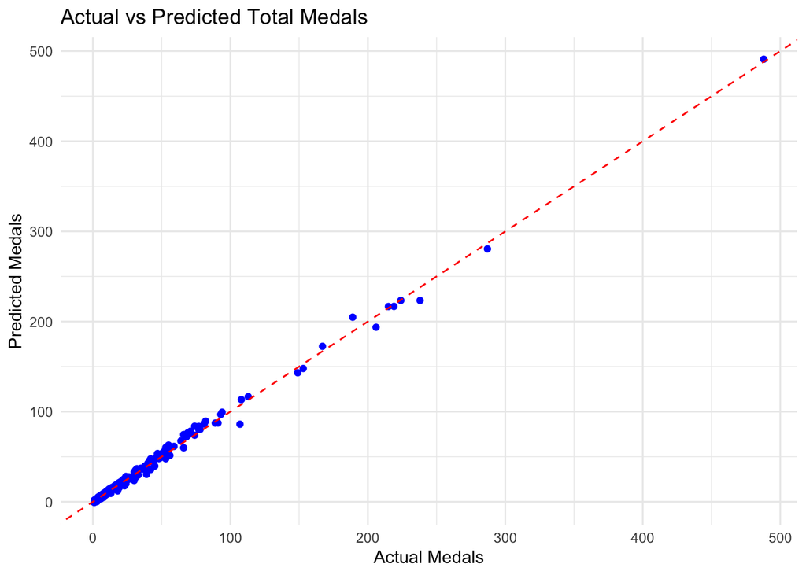

```r
# Plot actual vs predicted values
ggplot(predictions, aes(x = total_medals, y = .pred)) +
  geom_point(color = "blue") +
  geom_abline(slope = 1, intercept = 0, color = "red", linetype = "dashed") +
  labs(
    title = "Actual vs Predicted Total Medals",
    x = "Actual Medals",
    y = "Predicted Medals"
  ) +
  theme_minimal()
```

```r
tidy(trained_workflow)
```

```
## # A tibble: 7 × 5
##   term         estimate std.error statistic    p.value
##   <chr>           <dbl>     <dbl>     <dbl>      <dbl>
## 1 (Intercept)   19.6       0.0874   225.    0
## 2 num_athletes  37.6       0.0888   423.    0
## 3 avg_age        0.0611    0.0896     0.682 0.495
## 4 avg_height    -0.126     0.124     -1.01  0.311
## 5 avg_weight    -0.191     0.124     -1.54  0.125
## 6 year_poly_1  -17.1       3.56      -4.80  0.00000177
## 7 year_poly_2    4.58      3.53       1.30  0.194
```

```r
plot6 <- ggplot(medals_data, aes(x = num_athletes, y = total_medals)) +
  geom_point() +
  geom_smooth(method = "lm", col = "red", se = FALSE) +
  labs(title = "Medals vs Number of Athletes",
       x = "Number of Athletes",
       y = "Total Medals") +
  theme_minimal()

# Aggregating data by year for num_athletes, avg_age, avg_height, and avg_weight
athletes_by_year <- olympics %>%
  group_by(year) %>%
  summarise(
    num_athletes = n_distinct(id),        # Number of unique athletes per year
    avg_age = mean(age, na.rm = TRUE),     # Average age of athletes per year
    avg_height = mean(height, na.rm = TRUE), # Average height of athletes per year
    avg_weight = mean(weight, na.rm = TRUE), # Average weight of athletes per year
    .groups = 'drop'
  )

# Create plot for number of athletes by year
plot1 <- ggplot(athletes_by_year, aes(x = year, y = num_athletes)) +
  geom_line(color = "blue") +
  geom_point(color = "red") +
  labs(title = "Number of Athletes by Year",
       x = "Year",
       y = "Number of Athletes") +
  theme_minimal() +
  theme(axis.text.x = element_text(angle = 45, hjust = 1))  # Rotating x-axis labels

# Create plot for average age by year
plot2 <- ggplot(athletes_by_year, aes(x = year, y = avg_age)) +
  geom_line(color = "green") +
  geom_point(color = "orange") +
  labs(title = "Average Age of Athletes by Year",
       x = "Year",
       y = "Average Age") +
  theme_minimal() +
  theme(axis.text.x = element_text(angle = 45, hjust = 1))  # Rotating x-axis labels

# Create plot for average height by year
plot3 <- ggplot(athletes_by_year, aes(x = year, y = avg_height)) +
  geom_line(color = "purple") +
  geom_point(color = "yellow") +
  labs(title = "Average Height of Athletes by Year",
       x = "Year",
       y = "Average Height (cm)") +
  theme_minimal() +
  theme(axis.text.x = element_text(angle = 45, hjust = 1))  # Rotating x-axis labels

# Create plot for average weight by year
plot4 <- ggplot(athletes_by_year, aes(x = year, y = avg_weight)) +
  geom_line(color = "brown") +
  geom_point(color = "pink") +
  labs(title = "Average Weight of Athletes by Year",
       x = "Year",
       y = "Average Weight (kg)") +
  theme_minimal() +
  theme(axis.text.x = element_text(angle = 45, hjust = 1))  # Rotating x-axis labels




plot5 <- ggplot(
  data = olympics %>%
  filter(season == "Winter") %>%
  group_by(year) %>%
  summarise(total_medals = n(), .groups = 'drop'),
  aes(x = year, y = total_medals)) +
  geom_point() +
  geom_smooth(method = "lm", col = "purple", se = FALSE) +
  geom_smooth(method = "gam", col = "green", se = FALSE) +
  labs(title = "Total Medals Won by All Teams by Year",
       x = "Year",
       y = "Total Medals")
```